# Lesson 08 - Regression Simulation

## Instructions

Using the California dairy production dataset, perform time series analysis on the data for one of Cottage Cheese Production, Milk Production, or Ice Cream Production (your choice) to answer the following questions:

1. Is this time series stationary?
2. Is there a significant seasonal component?
3. For the residual from the STL decomposition of the time series, what is the order of the ARMA(p,q) process that best fits?

Then forecast production for 12 months and report both numeric values and plot the confidence intervals.

1. Are the confidence intervals reasonably small compared to the forecast means?
2. How do the confidence intervals behave as time moves to the future?

### Note

Please clearly outline the results with markdown text. Be sure your discussion includes narrative for your figures and tables so it is clear to the reader the importance of each bit of evidence.

```python
fileName = "https://library.startlearninglabs.uw.edu/DATASCI410/Datasets/CADairyProduction.csv"
```

```python
# Load necessary libraries
import pandas as pd
import numpy as np
from scipy.stats import zscore
import sklearn.linear_model as lm
import matplotlib.pyplot as plt
import statsmodels.graphics.tsaplots as splt
import seaborn as sns
sns.set()
%matplotlib inline
```

## Load and examine data

```python
# Load data
CMI_df = pd.read_csv(fileName)
CMI_df.head(3)
```

|  | Year | Month | Cotagecheese.Prod | Icecream.Prod | Milk.Prod | N.CA.Fat.Price | Month.Count | monthNumSqred | monthNumCubed |
| --- | --- | --- | --- | --- | --- | --- | --- | --- | --- |
| 0 | 1995 | Jan | 4.370 | 51.595 | 2.112 | 0.9803 | 1 | 1 | 1 |
| 1 | 1995 | Feb | 3.695 | 56.086 | 1.932 | 0.8924 | 2 | 4 | 8 |
| 2 | 1995 | Mar | 4.538 | 68.453 | 2.162 | 0.8924 | 3 | 9 | 27 |

```python
CMI_df.tail(3)
```

|  | Year | Month | Cotagecheese.Prod | Icecream.Prod | Milk.Prod | N.CA.Fat.Price | Month.Count | monthNumSqred | monthNumCubed |
| --- | --- | --- | --- | --- | --- | --- | --- | --- | --- |
| 225 | 2013 | Oct | 2.284 | 70.011 | 3.338 | 1.5566 | 226 | 51076 | 11543176 |
| 226 | 2013 | Nov | 1.865 | 61.394 | 3.275 | 1.7537 | 227 | 51529 | 11697083 |
| 227 | 2013 | Dec | 2.345 | 53.653 | 3.473 | 1.6747 | 228 | 51984 | 11852352 |

### Add time index to the dataset

```python
CMI_df.index = pd.date_range(start = '1-1995', end = '1-2014', freq = 'M')
CMI_df.head(3)
```

|  | Year | Month | Cotagecheese.Prod | Icecream.Prod | Milk.Prod | N.CA.Fat.Price | Month.Count | monthNumSqred | monthNumCubed |
| --- | --- | --- | --- | --- | --- | --- | --- | --- | --- |
| 1995-01-31 | 1995 | Jan | 4.370 | 51.595 | 2.112 | 0.9803 | 1 | 1 | 1 |
| 1995-02-28 | 1995 | Feb | 3.695 | 56.086 | 1.932 | 0.8924 | 2 | 4 | 8 |
| 1995-03-31 | 1995 | Mar | 4.538 | 68.453 | 2.162 | 0.8924 | 3 | 9 | 27 |

```python
CMI_df.tail(3)
```

|  | Year | Month | Cotagecheese.Prod | Icecream.Prod | Milk.Prod | N.CA.Fat.Price | Month.Count | monthNumSqred | monthNumCubed |
| --- | --- | --- | --- | --- | --- | --- | --- | --- | --- |
| 2013-10-31 | 2013 | Oct | 2.284 | 70.011 | 3.338 | 1.5566 | 226 | 51076 | 11543176 |
| 2013-11-30 | 2013 | Nov | 1.865 | 61.394 | 3.275 | 1.7537 | 227 | 51529 | 11697083 |
| 2013-12-31 | 2013 | Dec | 2.345 | 53.653 | 3.473 | 1.6747 | 228 | 51984 | 11852352 |

## Part 1. Perform time series analysis on the data for Milk Production to answer the following questions

### 1.1. Is this time series stationary?

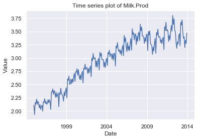

```python
def plot_ts(ts, lab = ''):
    """Plot time series ts with label lab."""
    ts.plot()
    plt.title('Time series plot of ' + lab)
    plt.ylabel('Value')
    plt.xlabel('Date')

plot_ts(CMI_df.loc[:, 'Milk.Prod'], 'Milk.Prod')
```

This chart shows that there is a strong trend in the milk production over time. Also, something happens at around year 2009 where there is a drop in production, and the trend resumes from a lower value and the curve has a larger seasonal amplitude.

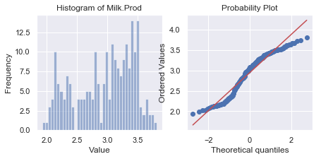

```python
def dist_ts(ts, lab = '', bins = 40):
    """Plot a hist and Q-Q curve for time series."""
    import scipy.stats as ss
    ## Setup a figure with two subplots side by side
    f, (ax1, ax2) = plt.subplots(1, 2, figsize=(7, 3))
    ## Plot the histogram with labels
    ts.hist(ax = ax1, bins = bins, alpha = 0.5)
    ax1.set_xlabel('Value')
    ax1.set_ylabel('Frequency')
    ax1.set_title('Histogram of ' + lab)
    ## Plot the q-q plot on the other axes
    ss.probplot(ts, plot = ax2)

dist_ts(CMI_df.loc[:, 'Milk.Prod'], 'Milk.Prod')
```

The histogram does not look normal. The quantiles curve is markedly S-shaped, reflecting that the distribution is not normal.

```
Figure(432x288)
Figure(432x288)
```

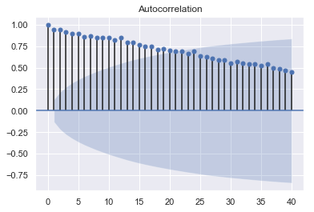

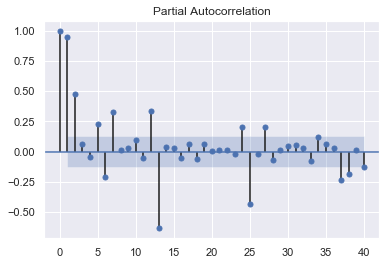

```python
# Plot autocorrelation and partial autocorrelation functions
print(splt.plot_acf(CMI_df.loc[:, 'Milk.Prod'], lags = 40))
print(splt.plot_pacf(CMI_df.loc[:, 'Milk.Prod'], lags = 40))
```

The ACF decays slowly and the PACF shows significant values for several lags. That means that there is a trend creating dependency from one value to the next. Thus, the milk production time series is **not stationary**.

### 1.2. Is there a significant seasonal component?

```python
import statsmodels.tsa.seasonal as sts
def decomp_ts(ts, freq = 'M', model = 'additive'):
    """Return a df with STL-decomposed time series."""
    res = sts.seasonal_decompose(ts, model = model) #, freq = freq)
    #resplot = res.plot()
    res.plot()
    return(pd.DataFrame({'resid': res.resid,
                         'trend': res.trend,
                         'seasonal': res.seasonal},
                        index = ts.index)
          )
```

```
              resid     trend  seasonal
1995-01-31      NaN       NaN  0.027271
1995-02-28      NaN       NaN -0.179759
1995-03-31      NaN       NaN  0.144447
1995-04-30      NaN       NaN  0.079891
1995-05-31      NaN       NaN  0.163026
1995-06-30      NaN       NaN  0.011056
1995-07-31  0.05312  2.110458  0.020421
```

|  | resid | trend | seasonal |
| --- | --- | --- | --- |
| 2013-06-30 | 0.042236 | 3.435708 | 0.011056 |
| 2013-07-31 | NaN | NaN | 0.020421 |
| 2013-08-31 | NaN | NaN | 0.003845 |
| 2013-09-30 | NaN | NaN | -0.119166 |
| 2013-10-31 | NaN | NaN | -0.024403 |
| 2013-11-30 | NaN | NaN | -0.117646 |
| 2013-12-31 | NaN | NaN | -0.008984 |

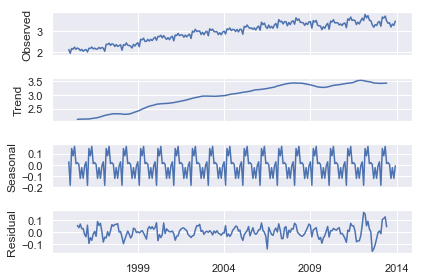

```python
decomp = decomp_ts(CMI_df.loc[:, 'Milk.Prod'])
print(decomp[:7])
decomp[-7:]
```

One of the above charts shows that **there is seasonal periodicity** in the series with a peak-to-peak amplitude which goes from minus 0.2 to plus 0.1.

### 1.3. For the residual from the STL decomposition of the time series, what is the order of the ARMA(p,q) process that best fits?

Dicky Fuller test to determine if the residual is stationary. Ho: time series is not stationary.

```python
def DF_Test(ts):
    """Compute and print adjusted Dicky Fuller test for time series."""
    from statsmodels.tsa.stattools import adfuller
    stationary = adfuller(ts)
    ## Print the results
    print('D-F statistic = ' + str(stationary[0]))
    print('p-value = ' + str(stationary[1]))
    print('number of lags used = ' + str(stationary[2]))
    print('Critical value at 5% confidence = ' + str(stationary[4]['5%']))
    print('Critical value at 10% confidence = ' + str(stationary[4]['10%']))
DF_Test(decomp.resid[6:-6])
```

```
D-F statistic = -5.102729220342753
p-value = 1.3842923938680073e-05
number of lags used = 14
Critical value at 5% confidence = -2.876029332045744
Critical value at 10% confidence = -2.5744932593252643
```

Given the DF statistic which is below the critical values and p-value near zero I can reject the null hypothesis that the residual is not stationary.

The code below looks for an ARIMA model order with the lowest BIC.

```python
def model_ARIMA_2(ts, order):
    """Helper function used by step_ARIMA()."""
    from statsmodels.tsa.arima_model import ARIMA
    from statsmodels.tsa.arima_model import ARIMAResults
    model = ARIMA(ts, order = order)
    model_fit = model.fit(disp=0, method='mle', trend='nc')
    BIC = ARIMAResults.bic(model_fit)
    print('Testing model of order: ' + str(order) + ' with BIC = ' + str(BIC))
    return(BIC, order, model_fit)


def step_ARIMA(resid, p_max, d_max, q_max):
    """Iterate over a grid of (p, d, q) values, return best model."""
    from statsmodels.tsa.arima_model import ARIMAResults
    from statsmodels.tsa.arima_model import ARIMA
    best_BIC = 9999999999999999.0
    for p in range(p_max + 1):
        for d in range(d_max + 1):
            for q in range(q_max + 1):
                if(p > 0 or q > 0):
                    try:
                        order = (p, d, q)
                        BIC, order, model = model_ARIMA_2(resid, order)
                        if(BIC < best_BIC):
                            best_model = model
                            best_BIC = BIC
                            best_order = order
                    except:
                        pass
    return(best_BIC, best_order, best_model)

BIC, order, model = step_ARIMA(decomp.resid[6:-6], 3, 3, 3)
print('***************************************')
print('Best model with BIC = ' + str(BIC) + ' and with order '+ str(order))
```

```
Testing model of order: (0, 0, 1) with BIC = -747.2053273053125
Testing model of order: (0, 0, 2) with BIC = -761.6974171906506
Testing model of order: (0, 0, 3) with BIC = -758.1534638214812
Testing model of order: (0, 1, 1) with BIC = -709.8792562744482
Testing model of order: (0, 1, 2) with BIC = -732.844677906798
Testing model of order: (0, 1, 3) with BIC = -747.7058433697621
Testing model of order: (0, 2, 1) with BIC = -688.6273216434323
Testing model of order: (1, 0, 0) with BIC = -761.5140236073962
Testing model of order: (1, 0, 1) with BIC = -756.3006605890359
Testing model of order: (1, 0, 2) with BIC = -751.8146732031621
Testing model of order: (1, 0, 3) with BIC = -774.6786267032585
Testing model of order: (1, 1, 0) with BIC = -708.979092117055
Testing model of order: (1, 1, 1) with BIC = -747.7752464587564
Testing model of order: (1, 1, 2) with BIC = -742.5289288933157
Testing model of order: (1, 1, 3) with BIC = -743.5184824397438
Testing model of order: (1, 2, 0) with BIC = -598.2335082046651
Testing model of order: (2, 0, 0) with BIC = -756.4453066413378
Testing model of order: (2, 0, 1) with BIC = -793.8216524733839
Testing model of order: (2, 0, 2) with BIC = -797.0659513209441
Testing model of order: (2, 0, 3) with BIC = -792.8722866404628
Testing model of order: (2, 1, 0) with BIC = -703.8194315936327
Testing model of order: (2, 1, 1) with BIC = -742.6370934548031
Testing model of order: (2, 2, 0) with BIC = -617.9370224492662
Testing model of order: (2, 2, 1) with BIC = -688.2980867653491
Testing model of order: (3, 0, 0) with BIC = -763.2934148829781
Testing model of order: (3, 0, 1) with BIC = -798.1544561497701
Testing model of order: (3, 0, 2) with BIC = -792.784199775564
Testing model of order: (3, 0, 3) with BIC = -786.6713854927525
Testing model of order: (3, 1, 0) with BIC = -700.4093131489967
Testing model of order: (3, 1, 1) with BIC = -748.9630500869091
Testing model of order: (3, 2, 0) with BIC = -619.8868082082608
Testing model of order: (3, 2, 1) with BIC = -684.7066907380066
Best model with BIC = -798.1544561497701 and with order (3, 0, 1)
```

**The best fitting ARMA(p, q) model is of the odrer (3, 1). There is also a third best fitting model with a close BIC of -793.8 but a smaller order of (2, 1).**

```python
# Calculate ARIMA model with the above parameters to see their summaries
def model_ARIMA(ts, order):
    """Return a fitted ARIMA model for time series and (p, d, q) order."""
    from statsmodels.tsa.arima_model import ARIMA
    model = ARIMA(ts, order = order)
    model_fit = model.fit(disp=0, method='mle', trend='nc')
    print(model_fit.summary())
    return(model_fit)

# Summary of ARIMA(3, 0, 1) model
model_ARIMA(decomp.resid[6:-6], (3, 0, 1))
```

```
                              ARMA Model Results
==============================================================================
Dep. Variable:                  resid   No. Observations:                  216
Model:                     ARMA(3, 1)   Log Likelihood                 412.515
Method:                           mle   S.D. of innovations              0.036
Date:                Sun, 03 Mar 2019   AIC                           -815.031
Time:                        16:20:12   BIC                           -798.154
Sample:                    07-31-1995   HQIC                          -808.213
                         - 06-30-2013
===============================================================================
                  coef    std err          z      P>|z|      [0.025      0.975]
-------------------------------------------------------------------------------
ar.L1.resid     1.2798      0.067     18.976      0.000       1.148       1.412
ar.L2.resid    -0.3204      0.109     -2.951      0.004      -0.533      -0.108
ar.L3.resid    -0.2159      0.068     -3.161      0.002      -0.350      -0.082
ma.L1.resid    -0.9755      0.018    -54.609      0.000      -1.011      -0.941
                                    Roots
=============================================================================
                  Real          Imaginary           Modulus         Frequency
-----------------------------------------------------------------------------
AR.1            1.0244           -0.5114j            1.1449           -0.0737
AR.2            1.0244           +0.5114j            1.1449            0.0737
AR.3           -3.5325           -0.0000j            3.5325           -0.5000
MA.1            1.0251           +0.0000j            1.0251            0.0000
-----------------------------------------------------------------------------
```

```
<statsmodels.tsa.arima_model.ARMAResultsWrapper at 0x1105b4358>
```

```python
# Summary of ARIMA(2, 0, 1) model
model_ARIMA(decomp.resid[6:-6], (2, 0, 1))
```

```
                              ARMA Model Results
==============================================================================
Dep. Variable:                  resid   No. Observations:                  216
Model:                     ARMA(2, 1)   Log Likelihood                 407.661
Method:                           mle   S.D. of innovations              0.036
Date:                Sun, 03 Mar 2019   AIC                           -807.323
Time:                        16:20:13   BIC                           -793.822
Sample:                    07-31-1995   HQIC                          -801.868
                         - 06-30-2013
===============================================================================
                  coef    std err          z      P>|z|      [0.025      0.975]
-------------------------------------------------------------------------------
ar.L1.resid     1.4133      0.054     26.214      0.000       1.308       1.519
ar.L2.resid    -0.6202      0.054    -11.460      0.000      -0.726      -0.514
ma.L1.resid    -0.9831      0.015    -67.204      0.000      -1.012      -0.954
                                    Roots
=============================================================================
                  Real          Imaginary           Modulus         Frequency
-----------------------------------------------------------------------------
AR.1            1.1393           -0.5606j            1.2698           -0.0728
AR.2            1.1393           +0.5606j            1.2698            0.0728
MA.1            1.0171           +0.0000j            1.0171            0.0000
-----------------------------------------------------------------------------
```

```
<statsmodels.tsa.arima_model.ARMAResultsWrapper at 0x1c23b68c50>
```

## Part 2. Forecast production for 12 months and report both numeric values and plot the confidence intervals

```python
CMI_df.columns
```

```
Index(['Year', 'Month', 'Cotagecheese.Prod', 'Icecream.Prod', 'Milk.Prod',
       'N.CA.Fat.Price', 'Month.Count', 'monthNumSqred', 'monthNumCubed'],
      dtype='object')
```

```python
# Normalize 'Month.Count', 'monthNumSqred', 'monthNumCubed'; to be used to model trend
CMI_df.loc[:, ['Month.Count',
               'monthNumSqred',
               'monthNumCubed']
          ] = CMI_df.loc[:, ['Month.Count',
                             'monthNumSqred',
                             'monthNumCubed']
                        ].apply(zscore)
```

```python
# Create dummy variables for the months; to be used to model the seasonal variation
years = int(len(CMI_df.loc[:, 'Milk.Prod']) / 12)
CMI_df.loc[:, 'Month'] = ['Jan', 'Feb', 'Mar', 'Apr', 'May', 'Jun', 'Jul',
                          'Aug', 'Sep', 'Oct', 'Nov', 'Dec'] * years
dummies = pd.get_dummies(CMI_df.loc[:, 'Month'])
CMI_df[list(dummies.columns)] = dummies
```

```python
# Print the head of the data frame to look at the dummy variables.
CMI_df.head(3)
```

|  | Year | Month | Cotagecheese.Prod | Icecream.Prod | Milk.Prod | N.CA.Fat.Price | Month.Count | monthNumSqred | monthNumCubed | Apr | ... | Dec | Feb | Jan | Jul | Jun | Mar | May | Nov | Oct | Sep |
| --- | --- | --- | --- | --- | --- | --- | --- | --- | --- | --- | --- | --- | --- | --- | --- | --- | --- | --- | --- | --- | --- |
| 1995-01-31 | 1995 | Jan | 4.370 | 51.595 | 2.112 | 0.9803 | -1.724471 | -1.120740 | -0.883649 | 0 | ... | 0 | 0 | 1 | 0 | 0 | 0 | 0 | 0 | 0 | 0 |
| 1995-02-28 | 1995 | Feb | 3.695 | 56.086 | 1.932 | 0.8924 | -1.709277 | -1.120548 | -0.883646 | 0 | ... | 0 | 1 | 0 | 0 | 0 | 0 | 0 | 0 | 0 | 0 |
| 1995-03-31 | 1995 | Mar | 4.538 | 68.453 | 2.162 | 0.8924 | -1.694084 | -1.120226 | -0.883641 | 0 | ... | 0 | 0 | 0 | 0 | 0 | 1 | 0 | 0 | 0 | 0 |

3 rows × 21 columns

#### Compute a linear regression model for coefficients of the trend and seasonal features

```python
# The final 12 months of data will be used to evaluate the model.
end_date = '2012-12-31'
start_date = '2013-01-31'
# Features are extracted into a numpy array
X = CMI_df.loc[:end_date,
               ['Month.Count', 'monthNumSqred', 'monthNumCubed',
                'Jan', 'Feb', 'Mar', 'Apr', 'May', 'Jun', 'Jul', 'Aug',
                'Sep', 'Oct', 'Nov', 'Dec']
              ].values
# Label is extracted into a numpy array
Y = CMI_df.loc[:end_date, 'Milk.Prod'].values
# Model is defined. No intercept is used since we have the seasonal
# component, which is a categorical feature
lm_mod = lm.LinearRegression(fit_intercept = False)
# Model fit is computed
mod_fit = lm_mod.fit(X, Y)

# Predictions of the trend and seasonal values are computed
CMI_df.loc[:end_date, 'scores'] = mod_fit.predict(X)
# Residuals with respect to these predictions are computed
CMI_df.loc[:end_date, 'resids'] = CMI_df.loc[:end_date, 'scores'] - CMI_df.loc[:end_date, 'Milk.Prod']
```

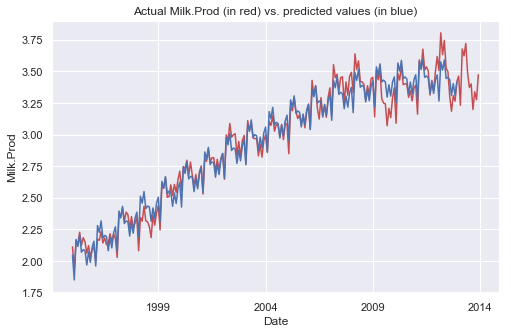

```python
# Look at how these predicted trend and seasonal components fit the actual milk production time series
def plot_mod_fit(df, col):
    import matplotlib.pyplot as plt
    fig = plt.figure(figsize=(8, 5))
    ax = fig.gca()
    df.loc[:, col].plot(color = 'r', ax = ax)
    df.loc[:, 'scores'].plot(ax = ax)
    ax.set_title('Actual ' + col + ' (in red) vs. predicted values (in blue)')
    ax.set_xlabel('Date')
    ax.set_ylabel(col)

plot_mod_fit(CMI_df, 'Milk.Prod')
```

#### RMSE

Compute the root mean square error (RMSE) of the fit of the model for the last 12 months of the milk production time series.

```python
def RMSE(ts, score):
    """Return RMSE of differences between values observed and values predicted."""
    from math import sqrt
    return sqrt(np.std(ts - score))

# Get source data for the forecast for the next year
X_test = CMI_df.loc[start_date:,
               ['Month.Count', 'monthNumSqred', 'monthNumCubed',
                'Jan', 'Feb', 'Mar', 'Apr', 'May', 'Jun', 'Jul', 'Aug',
                'Sep', 'Oct', 'Nov', 'Dec']
              ].values
# Make the forecast via mod_fit.predict(X_test) and evaluate it by RMSE
RMSE(CMI_df.loc[start_date:, 'Milk.Prod'].values, mod_fit.predict(X_test))
```

```
0.27442083630681086
```

```python
# Use sklearn to check the above calculations
from sklearn.metrics import mean_squared_error, r2_score
# The mean squared error
print("Root mean squared error: %.5f"
      % np.sqrt(mean_squared_error(CMI_df.loc[start_date:, 'Milk.Prod'].values,
                                   mod_fit.predict(X_test)))
     )
# Explained variance score: 1 is perfect prediction
print('Variance score: %.5f' % r2_score(CMI_df.loc[start_date:, 'Milk.Prod'].values,
                                        mod_fit.predict(X_test))
     )
```

```
Root mean squared error: 0.08413
Variance score: 0.73258
```

#### ARIMA model for the residual

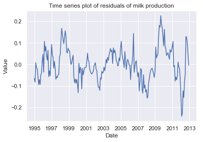

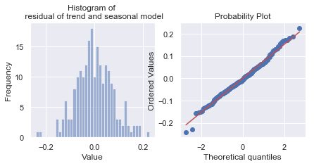

```python
# Look at a time series plot and distribution plots of the residuals
plot_ts(CMI_df.loc[:end_date, 'resids'], 'residuals of milk production')
dist_ts(CMI_df.loc[:end_date, 'resids'], '\n residual of trend and seasonal model')
```

The time series plot of the residual shows some minor periodic behavior with a couple of extreme values. The distribution plots show the values to be close to normally distributed.

Apply the **Dicky Fuller test** to see if the residual series is stationary.

```python
DF_Test(CMI_df.loc[:end_date, 'resids'])
```

```
D-F statistic = -4.133279522598512
p-value = 0.0008528635885795674
number of lags used = 14
Critical value at 5% confidence = -2.876029332045744
Critical value at 10% confidence = -2.5744932593252643
```

Given the DF statistic which is below the critical values and p-value near zero I can reject the null hypothesis that the residual is not stationary.

Compute an **ARIMA model** for the residual using the step_ARIMA function.

Train this model, without the last 12 months of data, which will be used to evaluate the model.

First, search for the best ARIMA mode order.

```python
BIC, order, arima_model_fit = step_ARIMA(CMI_df.loc[:end_date, 'resids'], 4, 3, 4)
print('Best order = ' + str(order) + ' best BIC = ' + str(BIC))
```

```
Testing model of order: (0, 0, 1) with BIC = -617.8015101295105
Testing model of order: (0, 0, 2) with BIC = -672.1516652690289
Testing model of order: (0, 0, 3) with BIC = -690.1634347110432
Testing model of order: (0, 0, 4) with BIC = -687.566164823812
Testing model of order: (0, 1, 1) with BIC = -700.9015560561647
Testing model of order: (0, 1, 2) with BIC = -695.5983663323367
Testing model of order: (0, 1, 3) with BIC = -694.1844733794835
Testing model of order: (0, 1, 4) with BIC = -690.8479435376207
Testing model of order: (0, 2, 1) with BIC = -684.3094081904807
Testing model of order: (1, 0, 0) with BIC = -718.3653338569468
Testing model of order: (1, 0, 1) with BIC = -714.5508098710668
Testing model of order: (1, 0, 2) with BIC = -711.674083391513
Testing model of order: (1, 0, 3) with BIC = -706.4193162887925
Testing model of order: (1, 0, 4) with BIC = -701.056832484762
Testing model of order: (1, 1, 0) with BIC = -701.1236951176397
Testing model of order: (1, 1, 1) with BIC = -695.7981603126929
Testing model of order: (1, 2, 0) with BIC = -600.7543134964916
Testing model of order: (1, 2, 1) with BIC = -685.7742267672264
Testing model of order: (1, 2, 2) with BIC = -680.48422139323
Testing model of order: (1, 2, 3) with BIC = -676.239112022365
Testing model of order: (1, 2, 4) with BIC = -671.7391743042299
Testing model of order: (2, 0, 0) with BIC = -714.9263059896962
Testing model of order: (2, 0, 1) with BIC = -710.1826492516288
Testing model of order: (2, 0, 2) with BIC = -706.3614627098548
Testing model of order: (2, 0, 3) with BIC = -704.1613373761322
Testing model of order: (2, 0, 4) with BIC = -700.8369095934161
Testing model of order: (2, 1, 0) with BIC = -695.7850854441068
Testing model of order: (2, 1, 1) with BIC = -690.4285799640822
Testing model of order: (2, 1, 2) with BIC = -698.5520082512023
Testing model of order: (2, 2, 0) with BIC = -621.4057773716244
Testing model of order: (2, 2, 1) with BIC = -680.46910787158
Testing model of order: (2, 2, 2) with BIC = -677.8912991237268
Testing model of order: (2, 2, 3) with BIC = -688.1066043374581
Testing model of order: (2, 2, 4) with BIC = -683.0584183522707
Testing model of order: (3, 0, 0) with BIC = -711.339239927325
Testing model of order: (3, 0, 1) with BIC = -706.1322438991817
Testing model of order: (3, 0, 2) with BIC = -705.9996752504048
Testing model of order: (3, 0, 3) with BIC = -701.4922381002093
Testing model of order: (3, 0, 4) with BIC = -708.8544860454779
Testing model of order: (3, 1, 0) with BIC = -690.7946966251939
Testing model of order: (3, 1, 1) with BIC = -699.5612523064067
Testing model of order: (3, 1, 2) with BIC = -694.3111828822197
Testing model of order: (3, 1, 3) with BIC = -694.2668550546298
Testing model of order: (3, 2, 0) with BIC = -622.1383260783934
Testing model of order: (3, 2, 1) with BIC = -675.4046307061443
Testing model of order: (3, 2, 2) with BIC = -675.0622070749155
Testing model of order: (3, 2, 3) with BIC = -683.0485299264693
```

```
Testing model of order: (3, 2, 4) with BIC = -682.1923372472264
Testing model of order: (4, 0, 0) with BIC = -706.3451986484106
Testing model of order: (4, 0, 1) with BIC = -708.1551682073773
Testing model of order: (4, 0, 2) with BIC = -713.47543416859
Testing model of order: (4, 0, 3) with BIC = -716.3884861489616
Testing model of order: (4, 0, 4) with BIC = -710.6239391809308
Testing model of order: (4, 1, 0) with BIC = -690.9291492619247
Testing model of order: (4, 1, 1) with BIC = -694.3178721053506
Testing model of order: (4, 1, 2) with BIC = -696.252031002841
Testing model of order: (4, 1, 3) with BIC = -701.7512611201032
```

```
Testing model of order: (4, 1, 4) with BIC = -686.3473166419757
Testing model of order: (4, 2, 0) with BIC = -644.6995351532197
Testing model of order: (4, 2, 1) with BIC = -675.2357724018927
Testing model of order: (4, 2, 2) with BIC = -678.7048564661769
Testing model of order: (4, 2, 3) with BIC = -677.9765188745306
Testing model of order: (4, 2, 4) with BIC = -681.3100849635202
Best order = (1, 0, 0) best BIC = -718.3653338569468
```

```python
arima_model_fit.summary()
```

ARMA Model Results

| Dep. Variable: | resids | No. Observations: | 216 |
| --- | --- | --- | --- |
| Model: | ARMA(1, 0) | Log Likelihood | 364.558 |
| Method: | mle | S.D. of innovations | 0.045 |
| Date: | Sun, 03 Mar 2019 | AIC | -725.116 |
| Time: | 16:20:32 | BIC | -718.365 |
| Sample: | 01-31-1995 | HQIC | -722.389 |
|  | - 12-31-2012 |  |  |

|  | coef | std err | z | P>\|z\| | [0.025 | 0.975] |
| --- | --- | --- | --- | --- | --- | --- |
| ar.L1.resids | 0.8074 | 0.040 | 20.404 | 0.000 | 0.730 | 0.885 |

Roots

|  | Real | Imaginary | Modulus | Frequency |
| --- | --- | --- | --- | --- |
| AR.1 | 1.2385 | +0.0000j | 1.2385 | 0.0000 |

```python
# Compute the best-fitting model on its own
model_ARIMA(CMI_df.loc[:end_date, 'resids'], (1, 0, 0))
```

```
                              ARMA Model Results
==============================================================================
Dep. Variable:                 resids   No. Observations:                  216
Model:                     ARMA(1, 0)   Log Likelihood                 364.558
Method:                           mle   S.D. of innovations              0.045
Date:                Sun, 03 Mar 2019   AIC                           -725.116
Time:                        16:20:32   BIC                           -718.365
Sample:                    01-31-1995   HQIC                          -722.389
                         - 12-31-2012
================================================================================
                   coef    std err          z      P>|z|      [0.025      0.975]
--------------------------------------------------------------------------------
ar.L1.resids     0.8074      0.040     20.404      0.000       0.730       0.885
                                    Roots
=============================================================================
                  Real          Imaginary           Modulus         Frequency
-----------------------------------------------------------------------------
AR.1            1.2385           +0.0000j            1.2385            0.0000
-----------------------------------------------------------------------------
```

```
<statsmodels.tsa.arima_model.ARMAResultsWrapper at 0x1c266a1d30>
```

#### Predictions from the ARIMA model

Compute ARIMA predictions of the residuals for the milk production for the last 12 months.

```python
# Try out different ARMA orders - redefine arima_model_fit; comment out before submission
# arima_model_fit = model_ARIMA(CMI_df.loc[:end_date, 'resids'], (1, 0, 1))

start_index = len(CMI_df.loc[:end_date, 'resids'])
end_index = start_index + 11
arima_model_prediction = arima_model_fit.predict(start=start_index, end=end_index)
arima_model_prediction
```

```
2013-01-31   -0.003377
2013-02-28   -0.002727
2013-03-31   -0.002201
2013-04-30   -0.001777
2013-05-31   -0.001435
2013-06-30   -0.001159
2013-07-31   -0.000936
2013-08-31   -0.000755
2013-09-30   -0.000610
2013-10-31   -0.000492
2013-11-30   -0.000398
2013-12-31   -0.000321
Freq: M, dtype: float64
```

Compute the prediction for the last 12 months of the milk production time series. The prediction is the combination of the trend, seasonal, and residual (ARIMA) models.

```python
# Get source data for the forecast for the next year
X_test = CMI_df.loc[start_date:,
            ['Month.Count', 'monthNumSqred', 'monthNumCubed', 'Jan', 'Feb',
             'Mar', 'Apr', 'May', 'Jun', 'Jul', 'Aug',
             'Sep', 'Oct', 'Nov', 'Dec']
           ].values
## and make predictions
CMI_df.loc[start_date:, 'scores'] =  mod_fit.predict(X_test) - arima_model_prediction
```

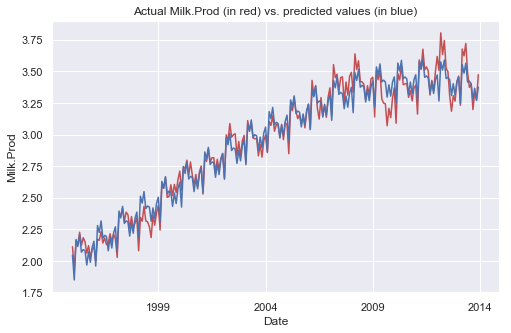

```python
# Plot the actual time series (in red) and the prediction (in blue)
plot_mod_fit(CMI_df, 'Milk.Prod')
```

Compute the **RMSE** and compare these results to the model with the trend and seasonal component only (which was 0.2744208363068114).

```python
# Use test data (actual) and predicted scores
RMSE(CMI_df.loc[start_date:, 'Milk.Prod'].values, CMI_df.loc[start_date:, 'scores'])
```

```
0.2740936326742926
```

The improvement is marginal, if any. Adding the ARIMA component to the model has **not improved** the prediction.

## RMSE functions comparision

```python
# RMSE function which I think should be used
def RMSE_expanded(ts, score):
    return np.sqrt(np.sum((ts - score)**2) / (len(score)))

RMSE_expanded(CMI_df.loc[start_date:, 'Milk.Prod'].values, CMI_df.loc[start_date:, 'scores'])
```

```
0.08337342724866598
```

```python
# The same function as above but shortened a bit
def RMSE_condensed(ts, score):
    return np.sqrt(np.mean((ts - score)**2))

RMSE_condensed(CMI_df.loc[start_date:, 'Milk.Prod'].values, CMI_df.loc[start_date:, 'scores'])
```

```
0.08337342724866599
```

```python
# Original function from the lesson with the extra sqrt element removed
def RMSE_lesson_no_sqrt(ts, score):
    from math import sqrt
    return np.std(ts - score)

# Original function from the lesson
def RMSE_original(ts, score):
    """Return RMSE of differences between values observed and values predicted."""
    from math import sqrt
    return sqrt(np.std(ts - score))

rmse_no_sqrt = RMSE_lesson_no_sqrt(CMI_df.loc[start_date:, 'Milk.Prod'].values,
                                   CMI_df.loc[start_date:, 'scores'])
rmse_orig = RMSE_original(CMI_df.loc[start_date:, 'Milk.Prod'].values,
                          CMI_df.loc[start_date:, 'scores'])
print('RMSE from the lesson materials, with sqrt removed and original:')
print(rmse_no_sqrt)
print(rmse_orig)
```

```
RMSE from the lesson materials, with sqrt removed and original:
0.07512731947259005
0.2740936326742926
```

```python
# Use sklearn to check the above calculations
from sklearn.metrics import mean_squared_error, r2_score
# The mean squared error
print("Root mean squared error: %.5f"
      % np.sqrt(mean_squared_error(CMI_df.loc[start_date:, 'Milk.Prod'].values,
                           CMI_df.loc[start_date:, 'scores']))
     )
# Explained variance score: 1 is perfect prediction
print('Variance score: %.5f' % r2_score(CMI_df.loc[start_date:, 'Milk.Prod'].values,
                                        CMI_df.loc[start_date:, 'scores'])
     )
```

```
Root mean squared error: 0.08337
Variance score: 0.73736
```

RMSE without the addition of the ARIMA preduction was 0.08413.

So, whichever function is used, it allows concluding that the improvement is marginal.

### Then forecast production for 12 months (DONE) and report both numeric values and plot the confidence intervals.

1. **Are the confidence intervals reasonably small compared to the forecast means?**</li>
2. **How do the confidence intervals behave as time moves to the future?**

Here I will first follow the approach suggested in the following post and then use the forecase() method of the statsmodels package:

https://datascience.stackexchange.com/questions/41934/obtaining-a-confidence-interval-for-the-prediction-of-a-linear-regression

```
You can estimate the standard deviation of your prediction:

stdev = np.sqrt(sum((linreg.predict(X_train) - y_train)**2) / (len(y_train) - 2))

Then, for any significance level you want, you should check correspondent Gaussian critical value (for example, for significance level 95% it is 1.96).

Finally, confidence intervals are (prediction - 1.96*stdev, prediction + 1.96*stdev) (or similarly for any other confidence level).
```

```python
# Reporting numeric values of the forecast
y_pred = CMI_df.loc[start_date:, 'scores']
print('Values predicted by the model:')
y_pred
```

```
Values predicted by the model:
```

```
2013-01-31    3.453654
2013-02-28    3.245001
2013-03-31    3.552709
2013-04-30    3.484753
2013-05-31    3.563448
2013-06-30    3.414556
2013-07-31    3.422174
2013-08-31    3.401517
2013-09-30    3.274740
2013-10-31    3.366116
2013-11-30    3.269362
2013-12-31    3.374139
Freq: M, Name: scores, dtype: float64
```

```python
# Calculate standard deviation
predicted_scores_train = CMI_df.loc[:end_date, 'scores']
actual_values_train = CMI_df.loc[:end_date, 'Milk.Prod']
stdev = np.sqrt(sum((predicted_scores_train - actual_values_train)**2) / (len(actual_values_train) - 2))
```

```python
# Calculate confidence intervals for 95% significance level
for prediction in y_pred:
    print('CI: ({:.3}, {:.3})'.format(prediction - 1.96 * stdev, prediction + 1.96 * stdev))
```

```
CI: (3.3, 3.6)
CI: (3.1, 3.39)
CI: (3.4, 3.7)
CI: (3.33, 3.63)
CI: (3.41, 3.71)
CI: (3.26, 3.56)
CI: (3.27, 3.57)
CI: (3.25, 3.55)
CI: (3.12, 3.42)
CI: (3.22, 3.52)
CI: (3.12, 3.42)
CI: (3.22, 3.52)
```

```python
# Calculate widths of confidence intervals
interval_widths = [(prediction + 1.96 * stdev) - (prediction - 1.96 * stdev) for prediction in y_pred]
print(interval_widths)
```

```
[0.29956859352798215, 0.29956859352798215, 0.29956859352798126, 0.29956859352798126, 0.29956859352798126, 0.29956859352798215, 0.29956859352798126, 0.29956859352798215, 0.29956859352798215, 0.29956859352798215, 0.29956859352798126, 0.29956859352798126]
```

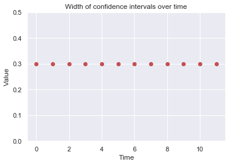

```python
# Plot widths of confidence intervals over time
plt.ylim(0, 0.5)
plt.xlabel('Time')
plt.ylabel('Value')
plt.title('Width of confidence intervals over time')
plt.plot(interval_widths, 'or')
```

This approach produced **equal-width confidence intervals** which do not change over time. On the contrary, the ARIMA forecast() method will produce confidence intervals which increase over time.

```python
print('The mean of the forecasts:')
np.mean(y_pred)
```

```
The mean of the forecasts:
```

```
3.4018473480910187
```

The width of the **confidence intervals** of about 0.3 is **small relative to the mean of the forecasts**.

## Attempt to apply ARIMA to calculate confidence intervals

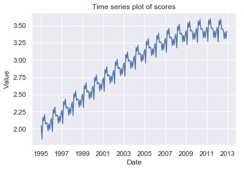

```python
# Are scores stationary?
scores_ts = CMI_df.loc[:end_date, 'scores']
plot_ts(scores_ts, 'scores')
```

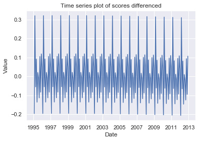

```python
# Apply differencing
scores_ts = scores_ts.diff()[1:]
plot_ts(scores_ts, 'scores differenced')
```

```python
BIC_diff, order_diff, arima_model_fit_scores = step_ARIMA(scores_ts, 4, 3, 4)
print('Best order = ' + str(order_diff) + ' best BIC = ' + str(BIC_diff))
```

```
Testing model of order: (0, 0, 1) with BIC = -337.8657035164985
Testing model of order: (0, 0, 2) with BIC = -339.6676136771548
Testing model of order: (0, 0, 3) with BIC = -347.25467214848123
Testing model of order: (0, 1, 1) with BIC = -232.7136139969711
Testing model of order: (0, 2, 1) with BIC = 18.953399917593536
Testing model of order: (1, 0, 0) with BIC = -343.64424826153214
Testing model of order: (1, 1, 0) with BIC = -183.2621969766779
Testing model of order: (1, 2, 0) with BIC = 44.27704050605748
Testing model of order: (2, 0, 0) with BIC = -345.11823137309875
Testing model of order: (2, 1, 0) with BIC = -267.0660008006209
Testing model of order: (2, 2, 0) with BIC = -117.34730984028997
Testing model of order: (3, 0, 0) with BIC = -341.9547910631629
Testing model of order: (3, 1, 0) with BIC = -266.20206349482544
Testing model of order: (3, 2, 0) with BIC = -129.66705528133224
Testing model of order: (4, 0, 0) with BIC = -348.3624648787225
Testing model of order: (4, 1, 0) with BIC = -311.38605456545395
Testing model of order: (4, 2, 0) with BIC = -234.38457410834388
Best order = (4, 0, 0) best BIC = -348.3624648787225
```

```python
arima_model_fit_scores.summary()
```

ARMA Model Results

| Dep. Variable: | scores | No. Observations: | 215 |
| --- | --- | --- | --- |
| Model: | ARMA(4, 0) | Log Likelihood | 187.608 |
| Method: | mle | S.D. of innovations | 0.101 |
| Date: | Sun, 03 Mar 2019 | AIC | -365.216 |
| Time: | 16:20:35 | BIC | -348.362 |
| Sample: | 02-28-1995 | HQIC | -358.406 |
|  | - 12-31-2012 |  |  |

|  | coef | std err | z | P>\|z\| | [0.025 | 0.975] |
| --- | --- | --- | --- | --- | --- | --- |
| ar.L1.scores | -0.6879 | 0.066 | -10.398 | 0.000 | -0.818 | -0.558 |
| ar.L2.scores | -0.1317 | 0.082 | -1.602 | 0.111 | -0.293 | 0.029 |
| ar.L3.scores | -0.0654 | 0.082 | -0.794 | 0.428 | -0.227 | 0.096 |
| ar.L4.scores | -0.2341 | 0.067 | -3.484 | 0.001 | -0.366 | -0.102 |

Roots

|  | Real | Imaginary | Modulus | Frequency |
| --- | --- | --- | --- | --- |
| AR.1 | -1.0397 | -0.6851j | 1.2451 | -0.4073 |
| AR.2 | -1.0397 | +0.6851j | 1.2451 | 0.4073 |
| AR.3 | 0.9000 | -1.3947j | 1.6599 | -0.1588 |
| AR.4 | 0.9000 | +1.3947j | 1.6599 | 0.1588 |

```python
# predict() method returns the same prediction as forecast()
# but if I skip the differencing step, then forecast() produces
# different results
start_index = len(scores_ts)
end_index = start_index + 11
arima_model_prediction_scores = arima_model_fit_scores.predict(start=start_index, end=end_index)
print('Preductions from predict() method of ARIMA:')
arima_model_prediction_scores
```

```
Preductions from predict() method of ARIMA:
```

```
2013-01-31   -0.037739
2013-02-28   -0.003716
2013-03-31    0.022765
2013-04-30   -0.037674
2013-05-31    0.031998
2013-06-30   -0.017670
2013-07-31    0.005075
2013-08-31    0.005564
2013-09-30   -0.010832
2013-10-31    0.010524
2013-11-30   -0.007366
2013-12-31    0.003087
Freq: M, dtype: float64
```

```python
# Use forecast() method to get predictions and CIs for 1 month
forecast, stderr, conf = arima_model_fit_scores.forecast()
# print('Expected: %.3f' % test[0])
print('Forecast: %.3f' % forecast)
print('Standard Error: %.3f' % stderr)
print('95%% Confidence Interval: %.3f to %.3f' % (conf[0][0], conf[0][1]))
```

```
Forecast: -0.038
Standard Error: 0.101
95% Confidence Interval: -0.236 to 0.160
```

```python
# And now, for 12 months
forecast, stderr, conf = arima_model_fit_scores.forecast(12)
```

```python
print('Forecasts from the Arima model on the scores:')
forecast
```

```
Forecasts from the Arima model on the scores:
```

```
array([-0.03773938, -0.00371618,  0.02276537, -0.03767359,  0.03199797,
       -0.01766982,  0.00507525,  0.00556362, -0.010832  ,  0.01052419,
       -0.00736554,  0.00308678])
```

```python
print('Confidence intervals from the Arima model:')
conf
```

```
Confidence intervals from the Arima model:
```

```
array([[-0.23554357,  0.16006481],
       [-0.24380802,  0.23637565],
       [-0.22665197,  0.27218272],
       [-0.29051877,  0.2151716 ],
       [-0.2214706 ,  0.28546653],
       [-0.27512443,  0.23978478],
       [-0.2557524 ,  0.2659029 ],
       [-0.2574317 ,  0.26855894],
       [-0.27434231,  0.25267832],
       [-0.25298781,  0.27403618],
       [-0.27108277,  0.25635168],
       [-0.2609936 ,  0.26716715]])
```

```
[0.39560838146559446, 0.4801836682536309, 0.4988346884841588, 0.5056903682954066, 0.5069371271272781, 0.5149092135075896, 0.5216553049724214, 0.5259906437755173, 0.5270206289731032, 0.5270239923999893, 0.5274344450159371, 0.5281607523482207]
```

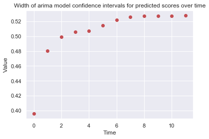

```python
# Calculate widths of confidence intervals
arima_interval_widths = [(conf[i][1] - conf[i][0]) for i in range(len(conf))]
print(arima_interval_widths)
# Plot widths of confidence intervals over time
plt.xlabel('Time')
plt.ylabel('Value')
plt.title('Width of arima model confidence intervals for predicted scores over time')
plt.plot(arima_interval_widths, 'or')
```

This calculation produces confidence intervals that increase over time. From what I understand, this is so because the standard errors are increasing, unlike in my first calculation where I used a constant value of the standard deviation for each confidence interval.